# HOJA DE TRABAJO 4 MODELOS DE REGRESION LINEAL

Raul Jimenez 19017 Donaldo Garcia 19683 Oscar Saravia 19322 link al repo: https://github.com/raulangelj/HT4_MRL

```python
# from re import U
from statsmodels.graphics.gofplots import qqplot
import numpy as np
import pandas as pd
# import pandasql as ps
import matplotlib.pyplot as plt
# import scipy.stats as stats
import statsmodels.stats.diagnostic as diag
# import statsmodels.api as sm
import seaborn as sns
# import random
import sklearn.cluster as cluster
# import sklearn.metrics as metrics
import sklearn.preprocessing
# import scipy.cluster.hierarchy as sch
import pyclustertend
from sklearn import tree
from sklearn.tree import DecisionTreeClassifier, DecisionTreeRegressor
from sklearn.ensemble import RandomForestClassifier
from sklearn import metrics
from sklearn.model_selection import train_test_split
from sklearn.linear_model import LinearRegression
from sklearn.metrics import mean_squared_error, r2_score
from scipy.stats import normaltest
from sklearn.linear_model import Ridge
from yellowbrick.regressor import ResidualsPlot
# import sklearn.mixture as mixture
# from sklearn import datasets
# from sklearn.cluster import DBSCAN
# from numpy import unique
# from numpy import where
# from matplotlib import pyplot
# from sklearn.datasets import make_classification
# from sklearn.cluster import Birch
# from sklearn.mixture import GaussianMixture


# %matplotlib inline
from mpl_toolkits.mplot3d import Axes3D
plt.rcParams['figure.figsize'] = (16, 9)
plt.style.use('ggplot')
```

## 1. Use los mismos conjuntos de entrenamiento y prueba que usó para los árboles de decisión en la hoja de trabajo anterior

## Datos obtenidos de HT3

Preprocesamiento y analisis de datos del lab anterior

```python
train = pd.read_csv('./train.csv', encoding='latin1')
train.head()
```

|  | Id | MSSubClass | MSZoning | LotFrontage | LotArea | Street | Alley | LotShape | LandContour | Utilities | ... | PoolArea | PoolQC | Fence | MiscFeature | MiscVal | MoSold | YrSold | SaleType | SaleCondition | SalePrice |
| --- | --- | --- | --- | --- | --- | --- | --- | --- | --- | --- | --- | --- | --- | --- | --- | --- | --- | --- | --- | --- | --- |
| 0 | 1 | 60 | RL | 65.0 | 8450 | Pave | NaN | Reg | Lvl | AllPub | ... | 0 | NaN | NaN | NaN | 0 | 2 | 2008 | WD | Normal | 208500 |
| 1 | 2 | 20 | RL | 80.0 | 9600 | Pave | NaN | Reg | Lvl | AllPub | ... | 0 | NaN | NaN | NaN | 0 | 5 | 2007 | WD | Normal | 181500 |
| 2 | 3 | 60 | RL | 68.0 | 11250 | Pave | NaN | IR1 | Lvl | AllPub | ... | 0 | NaN | NaN | NaN | 0 | 9 | 2008 | WD | Normal | 223500 |
| 3 | 4 | 70 | RL | 60.0 | 9550 | Pave | NaN | IR1 | Lvl | AllPub | ... | 0 | NaN | NaN | NaN | 0 | 2 | 2006 | WD | Abnorml | 140000 |
| 4 | 5 | 60 | RL | 84.0 | 14260 | Pave | NaN | IR1 | Lvl | AllPub | ... | 0 | NaN | NaN | NaN | 0 | 12 | 2008 | WD | Normal | 250000 |

5 rows × 81 columns

- SalePrice - **CUANTITATIVO CONTINUO** debido a que el precio puede tener centavos; the property's sale price in dollars. This is the target variable that you're trying to predict.
- LotArea: **CUANTITATIVO CONTINUO** Lot size in square feet
- OverallCond: **CUANTITATIVO DISCRETO** Overall condition rating
- YearBuilt: **CUANTITATIVO DISCRETO** Original construction date
- MasVnrArea: **CUANTITATIVO CONTINUO** Masonry veneer area in square feet
- TotalBsmtSF: **CUANTITATIVO CONTINUO** Total square feet of basement area
- 1stFlrSF: **CUANTITATIVO CONTINUO** First Floor square feet
- 2ndFlrSF: **CUANTITATIVO CONTINUO** Second floor square feet
- GrLivArea: **CUANTITATIVO CONTINUO** Above grade (ground) living area square feet
- TotRmsAbvGrd: **CUANTITATIVO DISCRETO** Total rooms above grade (does not include bathrooms)
- GarageCars: **CUANTITATIVO DISCRETO** Size of garage in car capacity
- WoodDeckSF: **CUANTITATIVO CONTINUO** Wood deck area in square feet
- OpenPorchSF: **CUANTITATIVO CONTINUO** Open porch area in square feet
- EnclosedPorch: **CUANTITATIVO CONTINUO** Enclosed porch area in square feet
- PoolArea: **CUANTITATIVO CONTINUO** Pool area in square feet
- Neighborhood: **CUALITATIVO NOMINAL** Physical locations within Ames city limits

```python
usefullAttr = ['SalePrice', 'LotArea', 'OverallCond', 'YearBuilt', 'MasVnrArea', 'TotalBsmtSF', '1stFlrSF',
               '2ndFlrSF', 'GrLivArea', 'TotRmsAbvGrd', 'GarageCars', 'WoodDeckSF', 'OpenPorchSF', 'EnclosedPorch', 'PoolArea', 'Neighborhood', 'OverallQual']
```

```python
data = train[usefullAttr]
data.head()
```

|  | SalePrice | LotArea | OverallCond | YearBuilt | MasVnrArea | TotalBsmtSF | 1stFlrSF | 2ndFlrSF | GrLivArea | TotRmsAbvGrd | GarageCars | WoodDeckSF | OpenPorchSF | EnclosedPorch | PoolArea | Neighborhood | OverallQual |
| --- | --- | --- | --- | --- | --- | --- | --- | --- | --- | --- | --- | --- | --- | --- | --- | --- | --- |
| 0 | 208500 | 8450 | 5 | 2003 | 196.0 | 856 | 856 | 854 | 1710 | 8 | 2 | 0 | 61 | 0 | 0 | CollgCr | 7 |
| 1 | 181500 | 9600 | 8 | 1976 | 0.0 | 1262 | 1262 | 0 | 1262 | 6 | 2 | 298 | 0 | 0 | 0 | Veenker | 6 |
| 2 | 223500 | 11250 | 5 | 2001 | 162.0 | 920 | 920 | 866 | 1786 | 6 | 2 | 0 | 42 | 0 | 0 | CollgCr | 7 |
| 3 | 140000 | 9550 | 5 | 1915 | 0.0 | 756 | 961 | 756 | 1717 | 7 | 3 | 0 | 35 | 272 | 0 | Crawfor | 7 |
| 4 | 250000 | 14260 | 5 | 2000 | 350.0 | 1145 | 1145 | 1053 | 2198 | 9 | 3 | 192 | 84 | 0 | 0 | NoRidge | 8 |

### GRAFICAS DE VARIABLES

```python
def get_histogram_qq(variable):
    plt.hist(x=data[variable] .dropna(), color='#F2AB6D', rwidth=1)
    plt.title(f'Histograma de la variable{variable}')
    plt.xlabel(variable)
    plt.ylabel('frencuencias')
    plt.rcParams['figure.figsize'] = (30, 30)
    plt.show()

    distribucion_generada = data[variable].dropna()
    # Represento el Q-Q plot
    qqplot(distribucion_generada, line='s')
    plt.show()
```

#### SalePricee

Se puede determinar que la variable SalePrice no sigue una disctribucion normal debido a que el histograma no sigue una forma de campana y el diagrama QQ nos muestra que los datos son muy distintos.

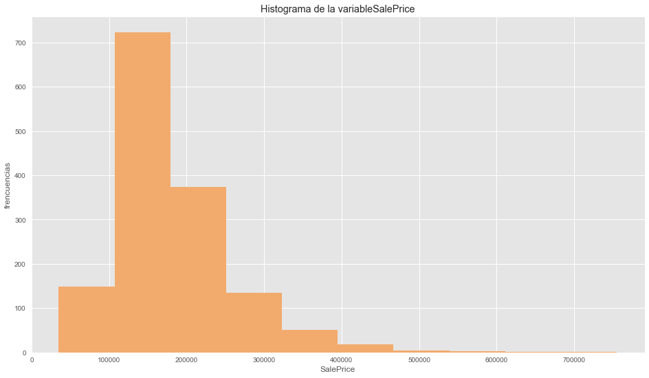

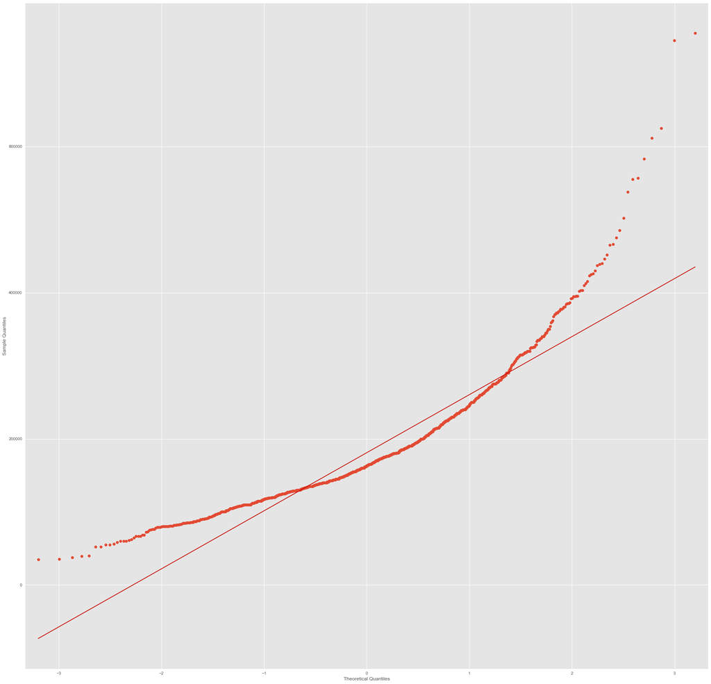

```python
get_histogram_qq('SalePrice')
```

#### LotArea

Se puede determinar que la variable LotArea no sigue una disctribucion normal debido a que el histograma no sigue una forma de campana y el diagrama QQ nos muestra que los datos son muy distintos.

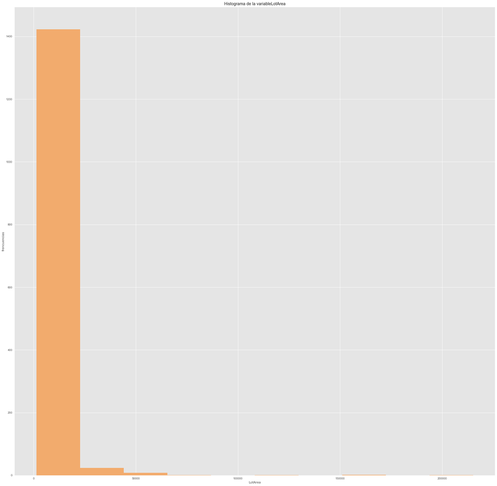

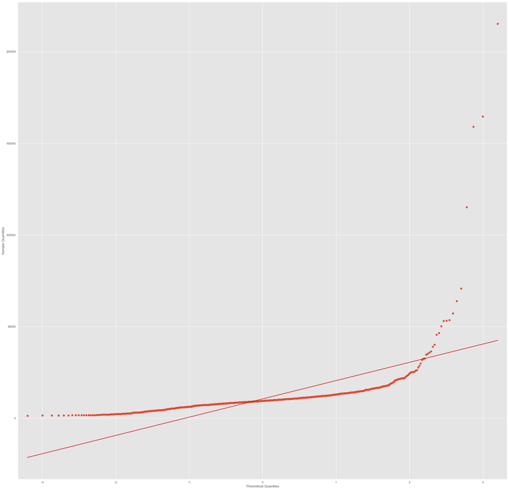

```python
get_histogram_qq('LotArea')
```

#### OverallCond

Se puede determinar que la variable OverallCond no sigue una disctribucion normal debido a que el histograma no sigue una forma de campana y el diagrama QQ nos muestra que los datos son muy distintos.

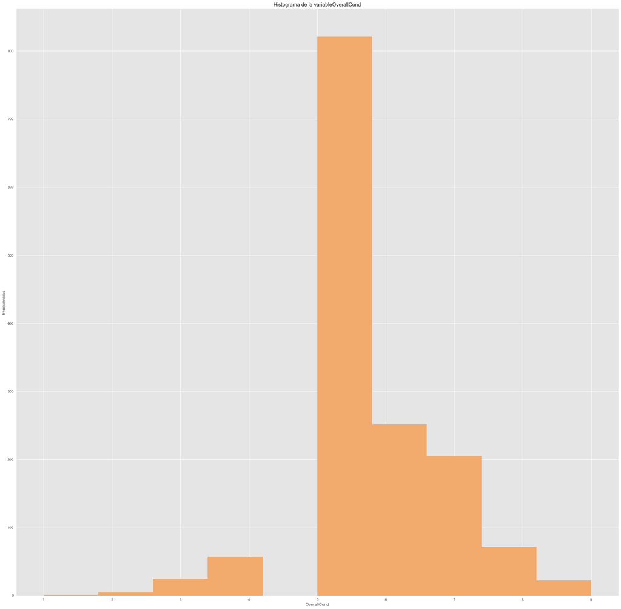

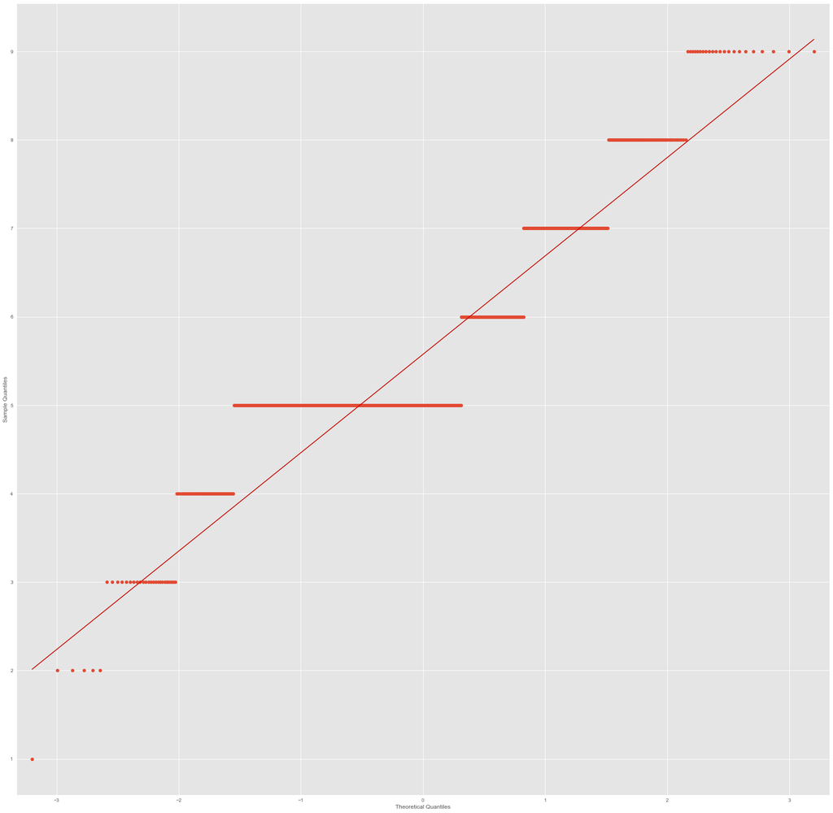

```python
get_histogram_qq('OverallCond')
```

#### YearBuilt

Se puede determinar que la variable YearBuilt no sigue una disctribucion normal debido a que el histograma no sigue una forma de campana y el diagrama QQ nos muestra que los datos son muy distintos.

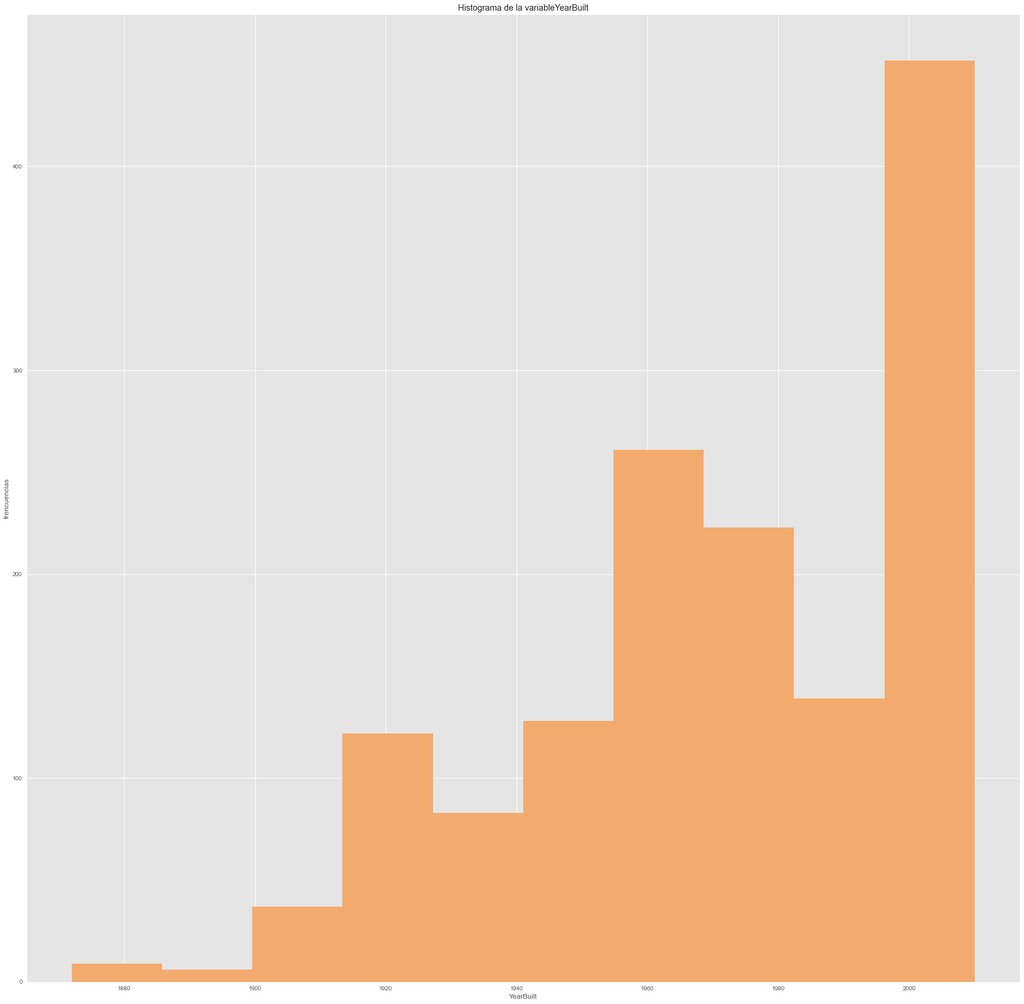

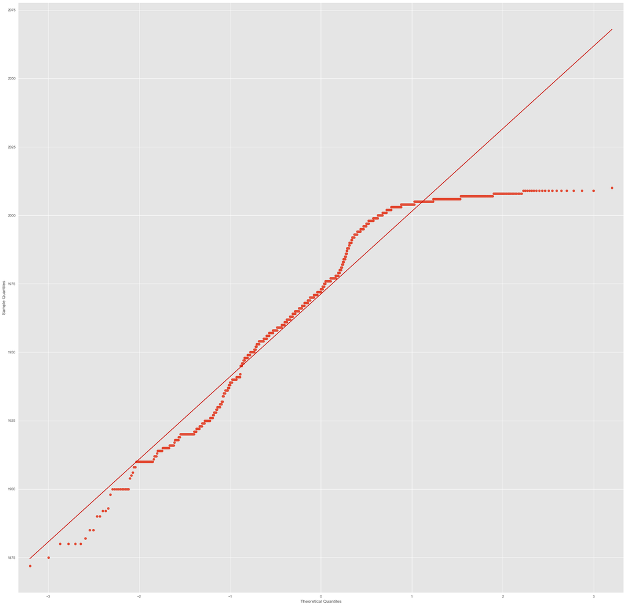

```python
get_histogram_qq('YearBuilt')
```

#### MasVnrArea

Se puede determinar que la variable MasVnrArea no sigue una disctribucion normal debido a que el histograma no sigue una forma de campana y el diagrama QQ nos muestra que los datos son muy distintos.

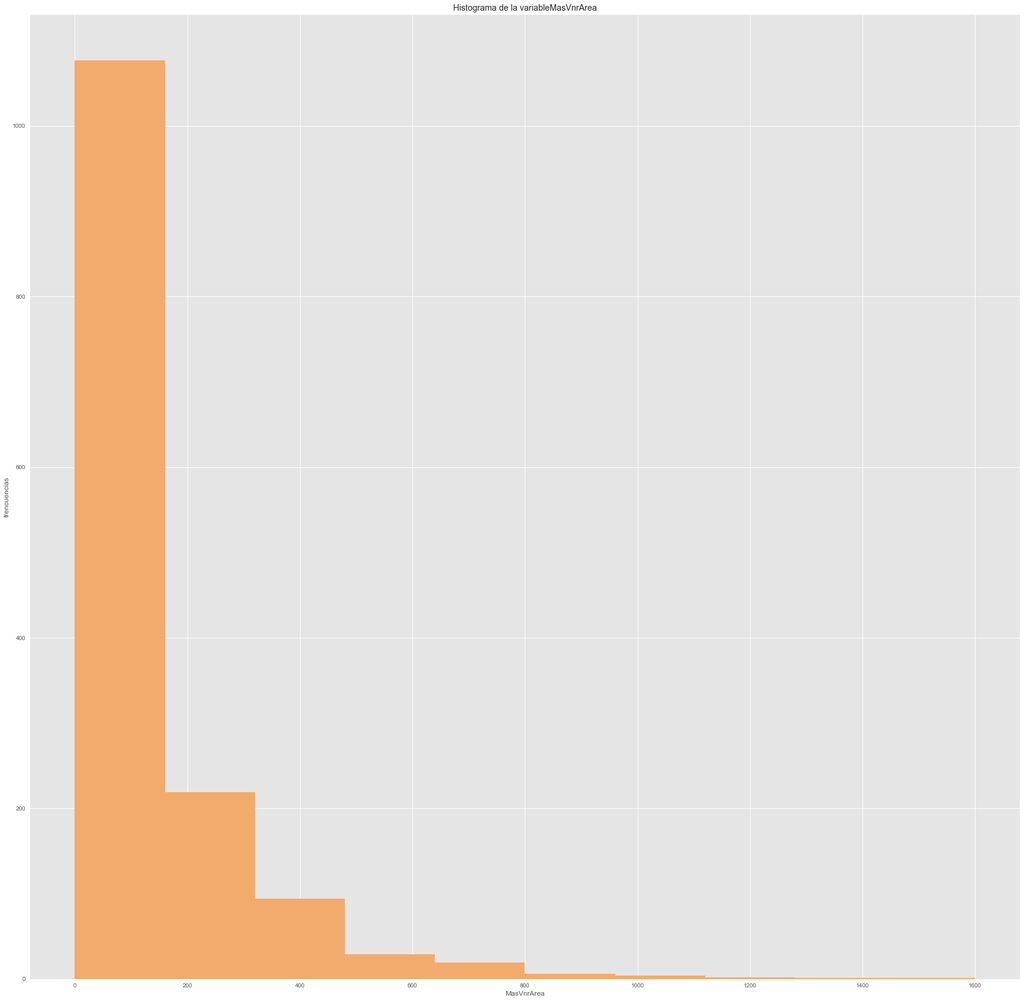

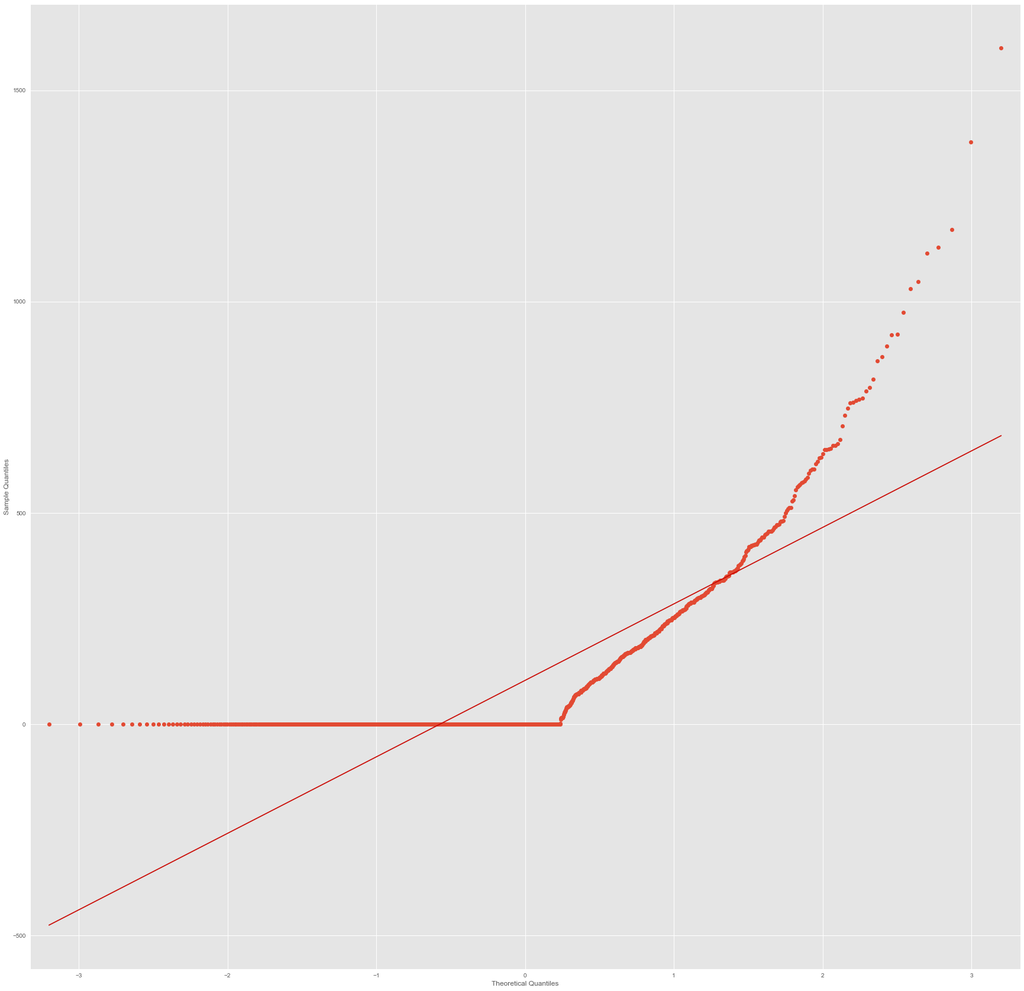

```python
get_histogram_qq('MasVnrArea')
```

#### TotalBsmtSF

Se puede determinar que la variable TotalBsmtSF no sigue una disctribucion normal debido a que el histograma no sigue una forma de campana y el diagrama QQ nos muestra que los datos son muy distintos.

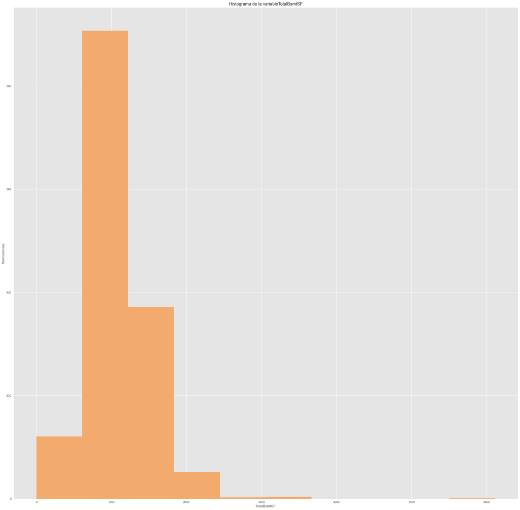

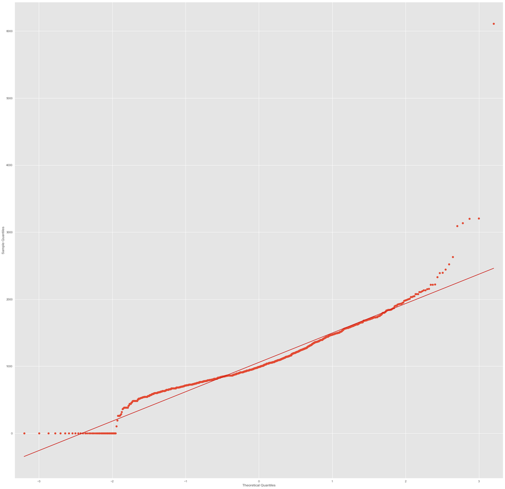

```python
get_histogram_qq('TotalBsmtSF')
```

#### 1stFlrSF

Se puede determinar que la variable 1stFlrSF no sigue una disctribucion normal debido a que el histograma no sigue una forma de campana y el diagrama QQ nos muestra que los datos son muy distintos.

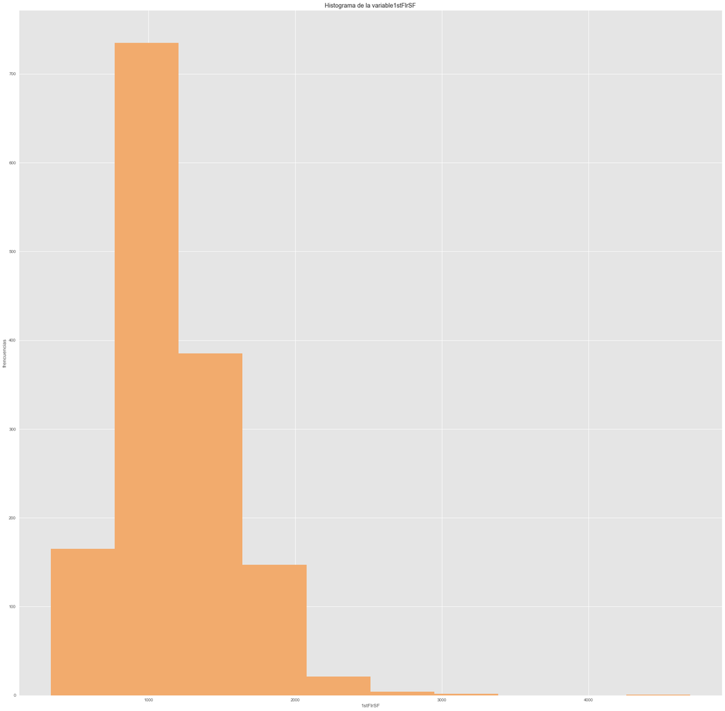

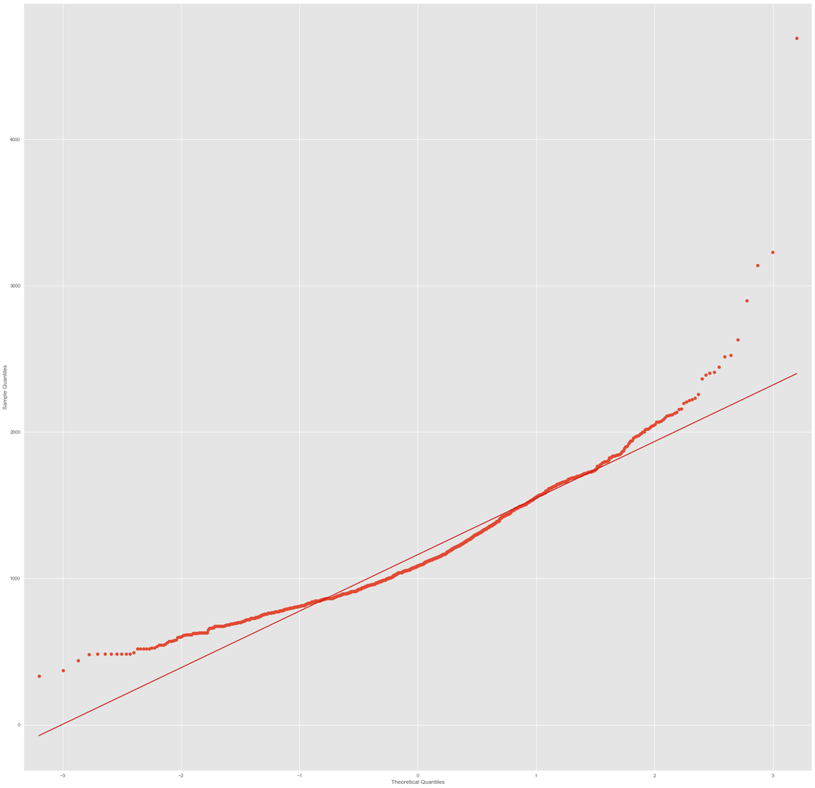

```python
get_histogram_qq('1stFlrSF')
```

#### 2ndFlrSF

Se puede determinar que la variable 2ndFlrSF no sigue una disctribucion normal debido a que el histograma no sigue una forma de campana y el diagrama QQ nos muestra que los datos son muy distintos.

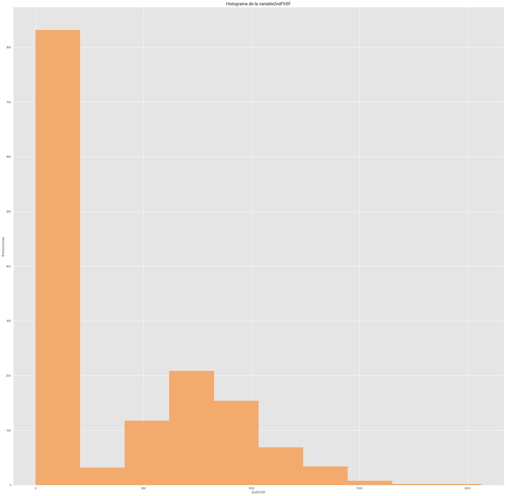

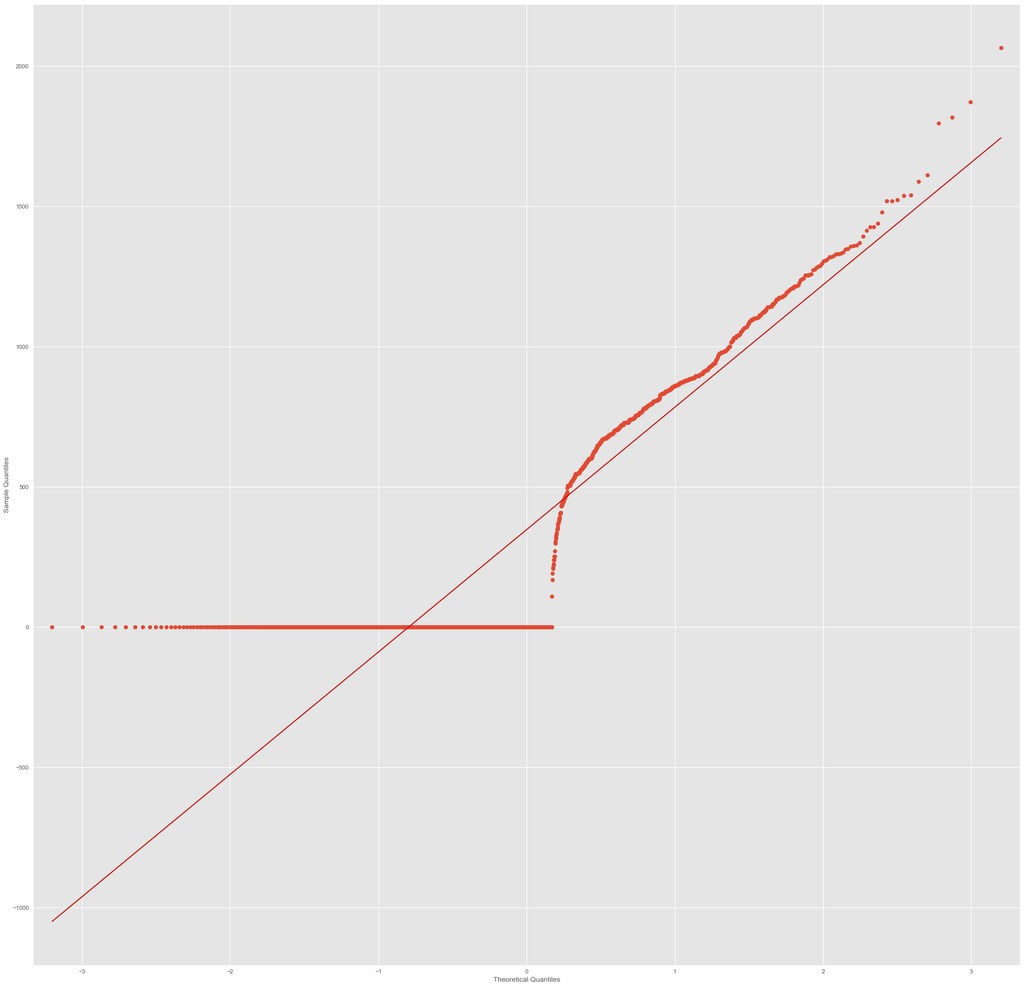

```python
get_histogram_qq('2ndFlrSF')
```

#### GrLivArea

Se puede determinar que la variable GrLivArea no sigue una disctribucion normal debido a que el histograma no sigue una forma de campana y el diagrama QQ nos muestra que los datos son muy distintos.

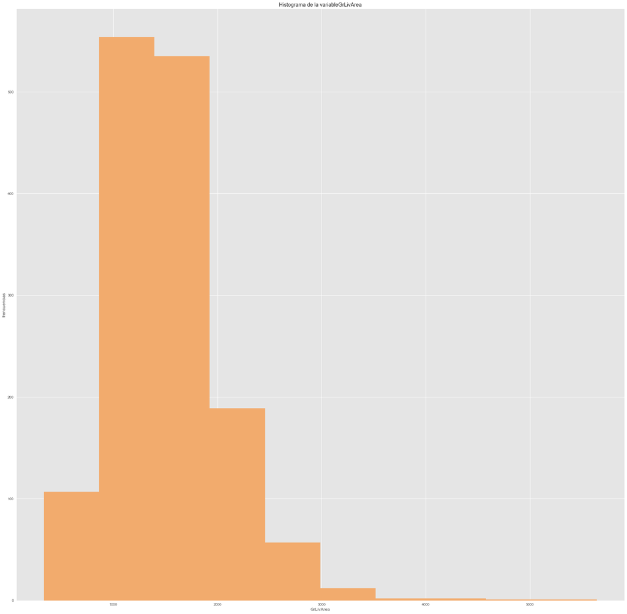

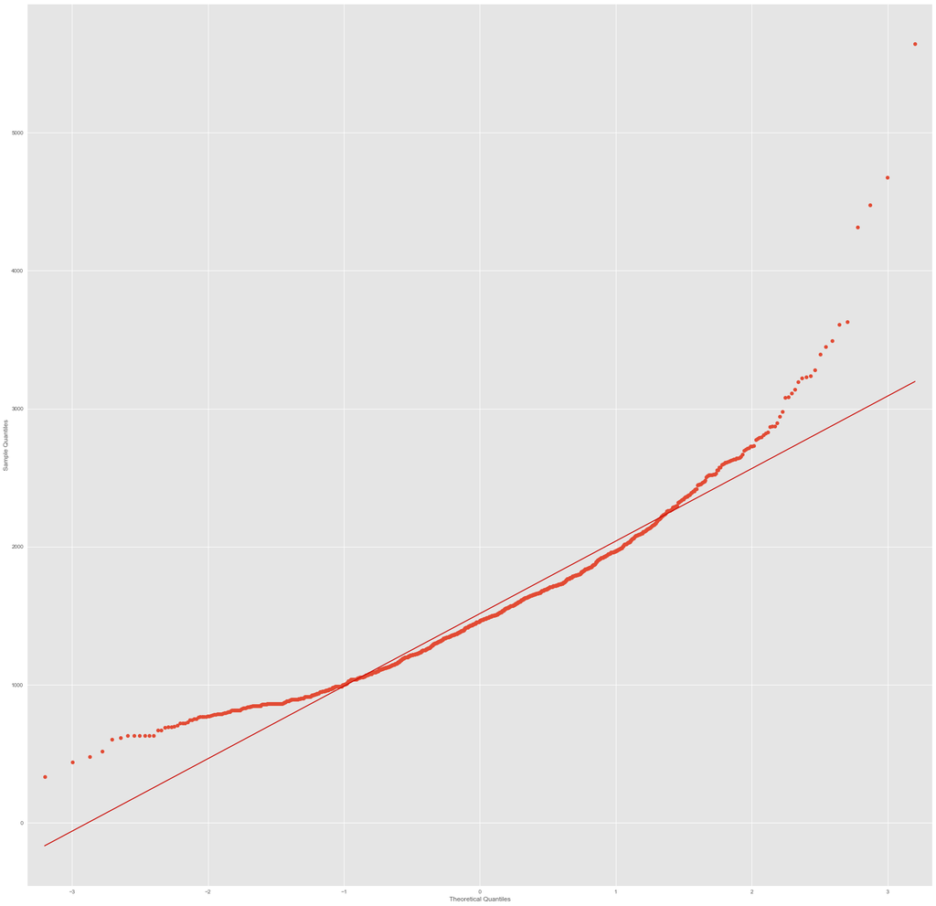

```python
get_histogram_qq('GrLivArea')
```

#### TotRmsAbvGrd

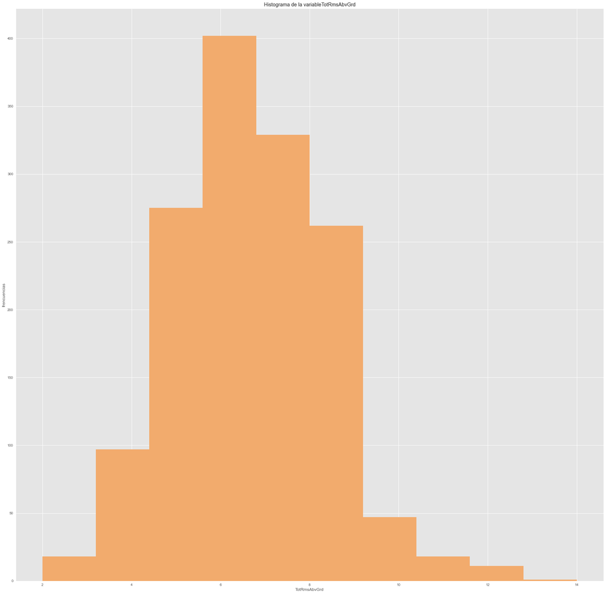

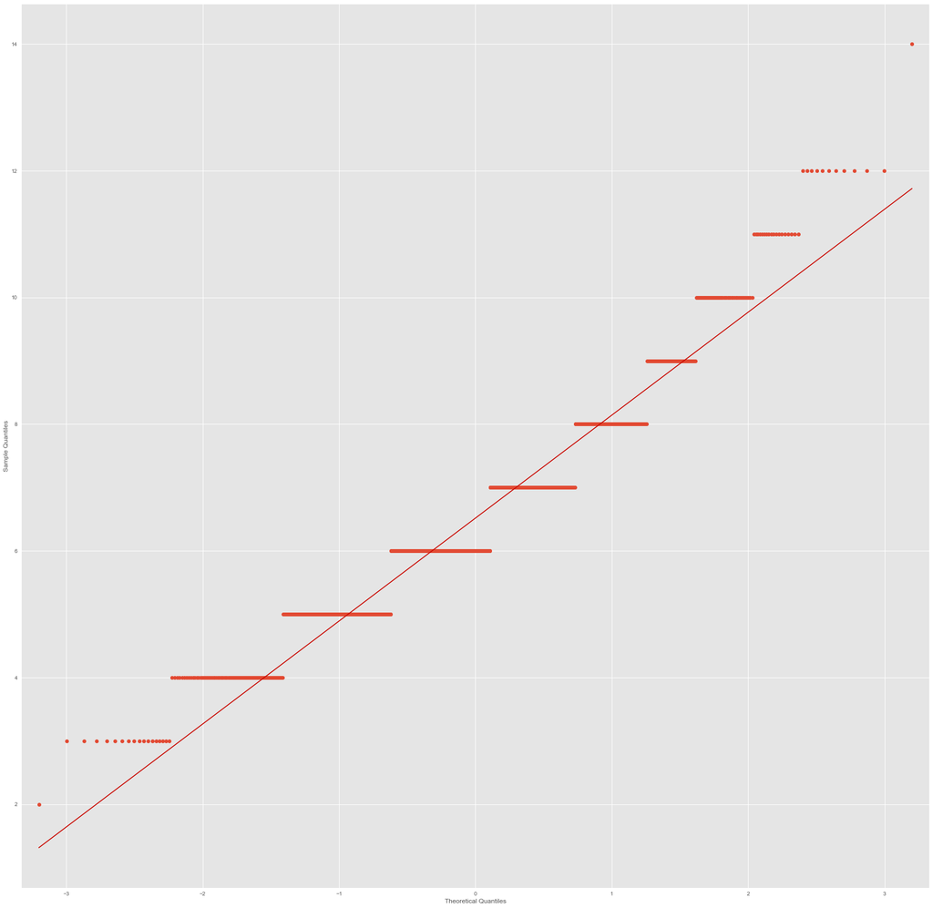

```python
get_histogram_qq('TotRmsAbvGrd')
```

#### GarageCars

Se puede determinar que la variable GarageCars no sigue una disctribucion normal debido a que el histograma no sigue una forma de campana y el diagrama QQ nos muestra que los datos son muy distintos.

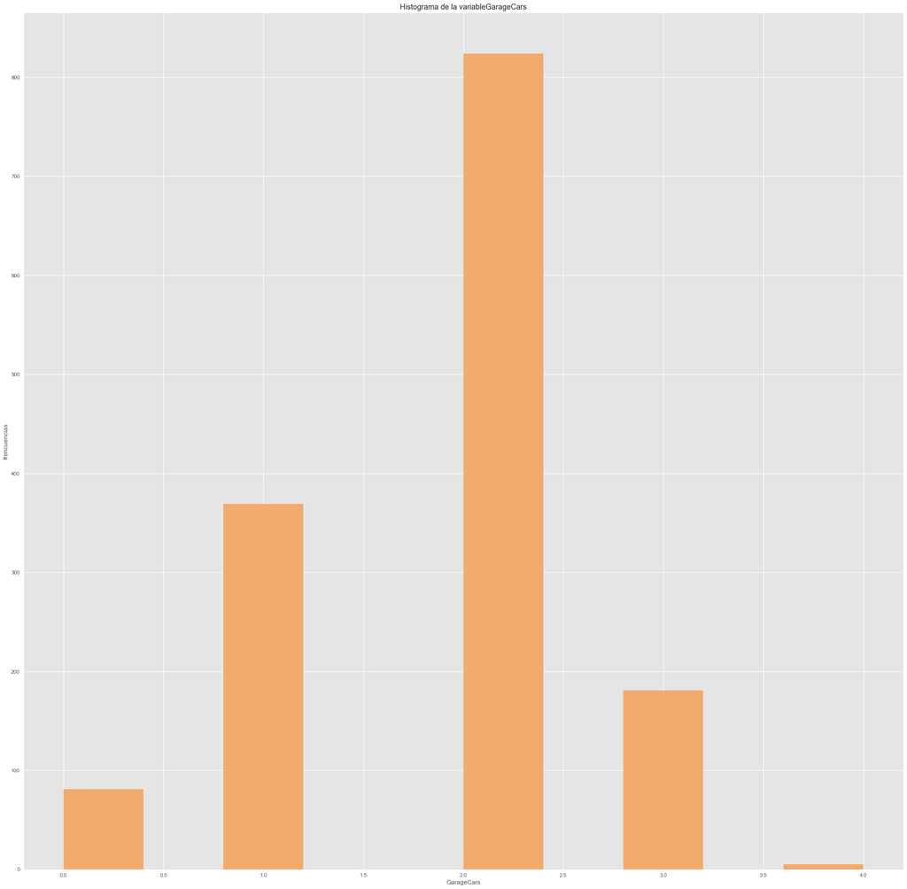

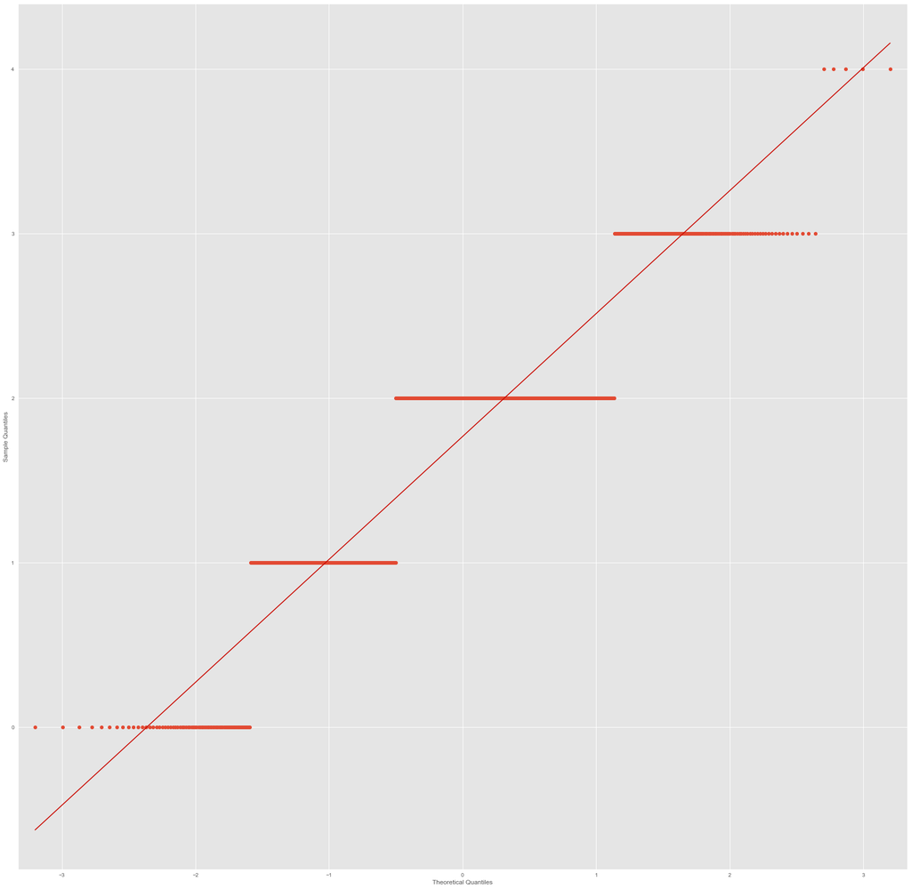

```python
get_histogram_qq('GarageCars')
```

#### WoodDeckSF

Se puede determinar que la variable WoodDeckSF no sigue una disctribucion normal debido a que el histograma no sigue una forma de campana y el diagrama QQ nos muestra que los datos son muy distintos.

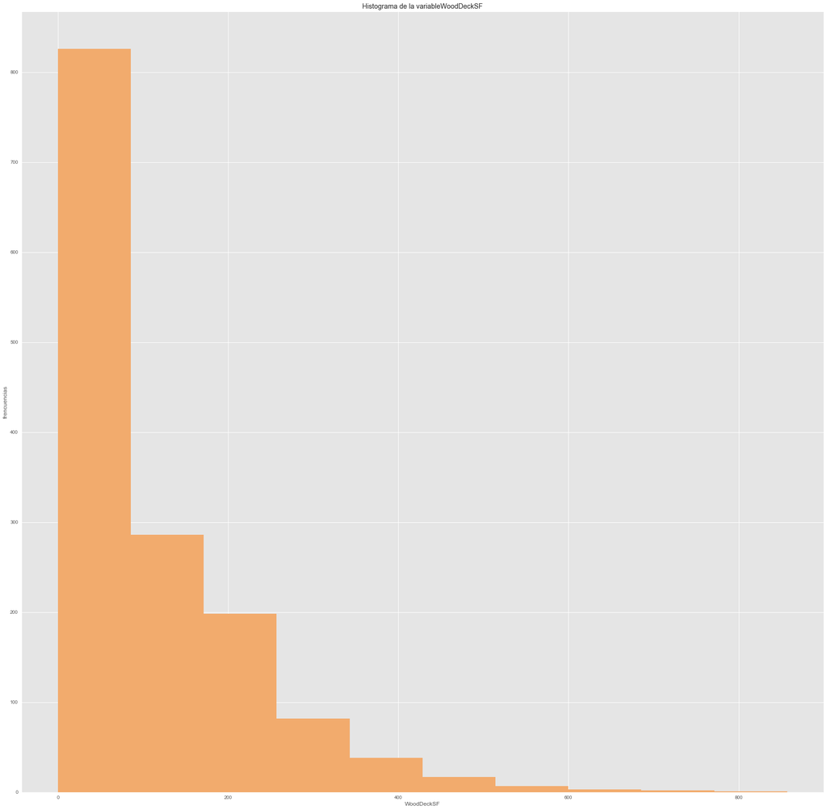

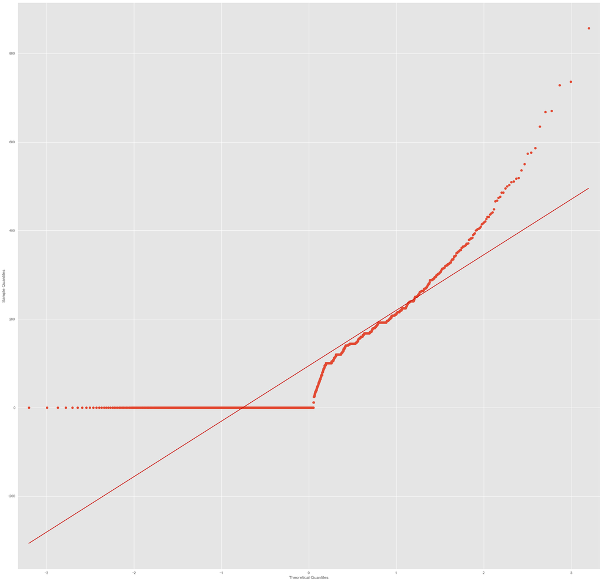

```python
get_histogram_qq('WoodDeckSF')
```

#### OpenPorchSF

Se puede determinar que la variable OpenPorchSF no sigue una disctribucion normal debido a que el histograma no sigue una forma de campana y el diagrama QQ nos muestra que los datos son muy distintos.

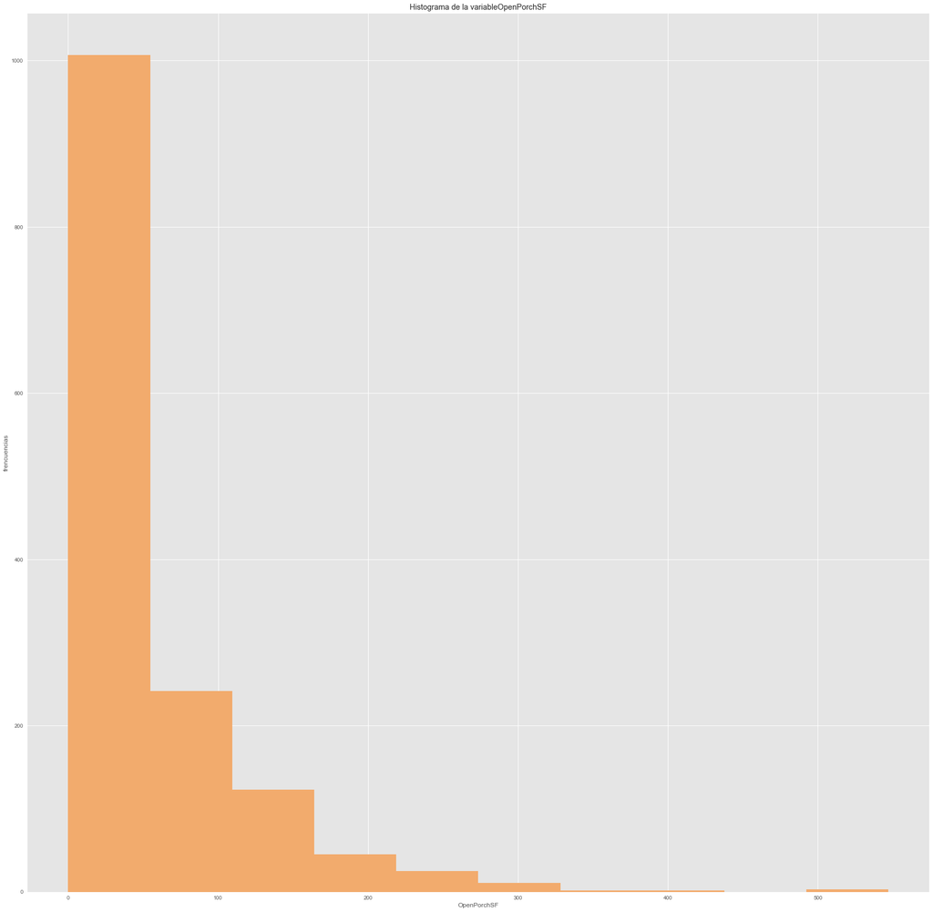

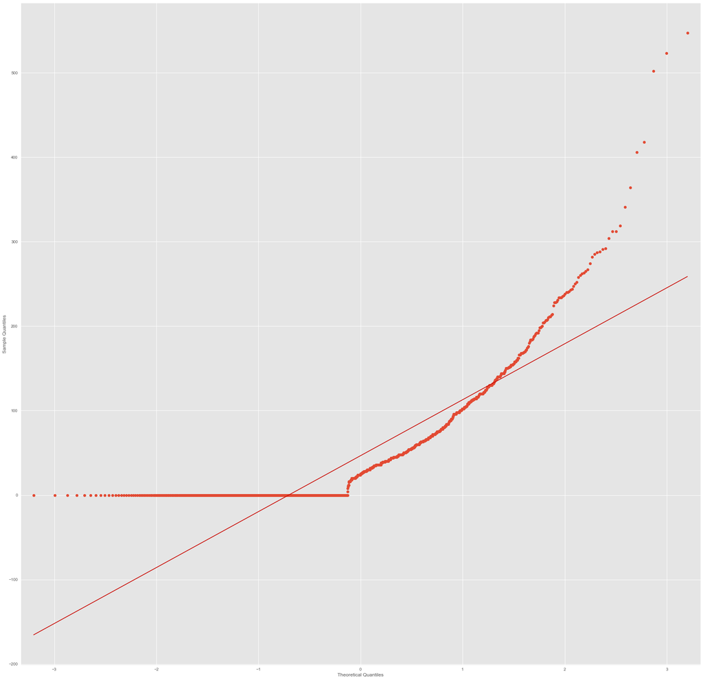

```python
get_histogram_qq('OpenPorchSF')
```

#### EnclosedPorch

Se puede determinar que la variable EnclosedPorch no sigue una disctribucion normal debido a que el histograma no sigue una forma de campana y el diagrama QQ nos muestra que los datos son muy distintos.

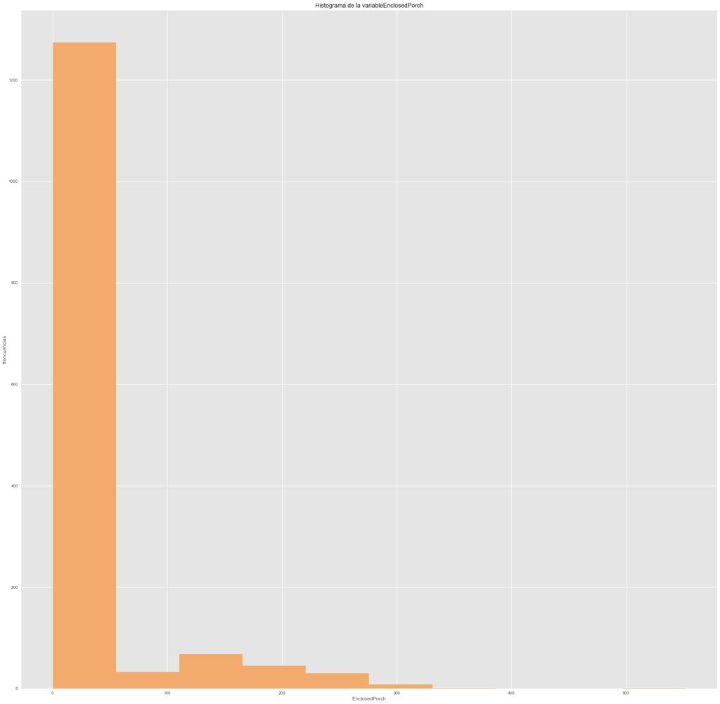

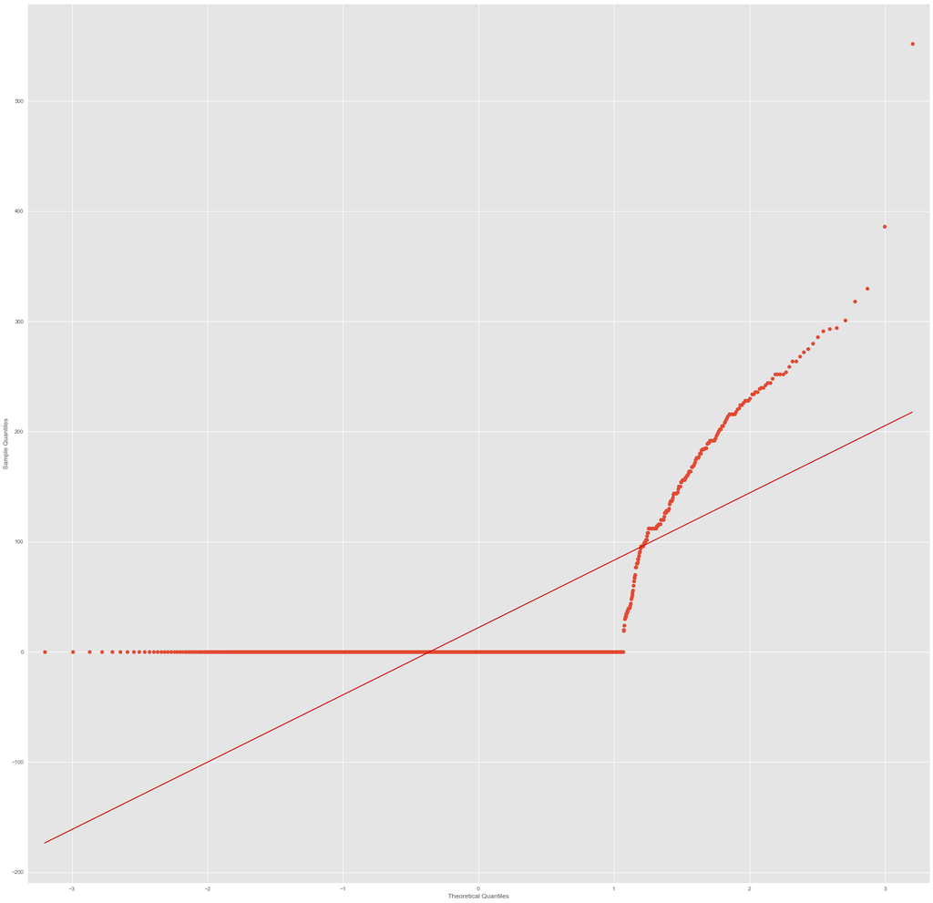

```python
get_histogram_qq('EnclosedPorch')
```

#### PoolArea

Se puede determinar que la variable PoolArea no sigue una disctribucion normal debido a que el histograma no sigue una forma de campana y el diagrama QQ nos muestra que los datos son muy distintos.

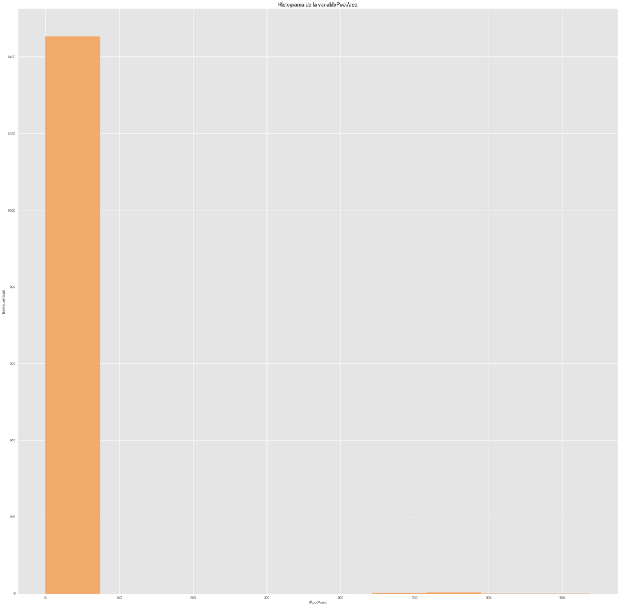

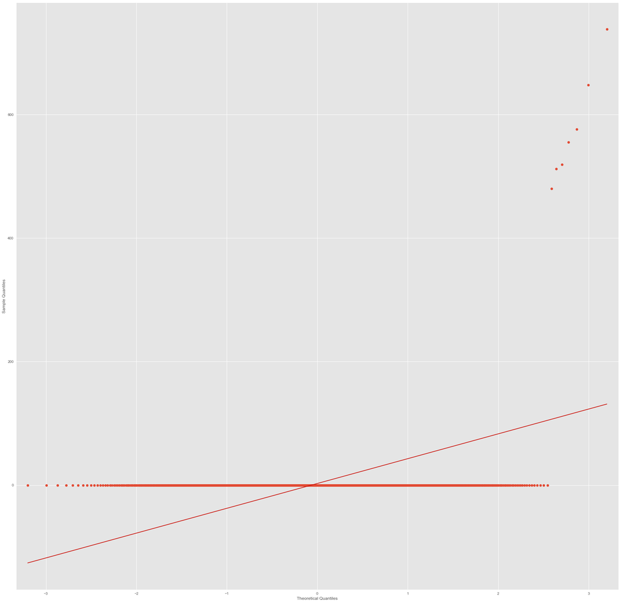

```python
get_histogram_qq('PoolArea')
```